# The Immigrant Climate Index

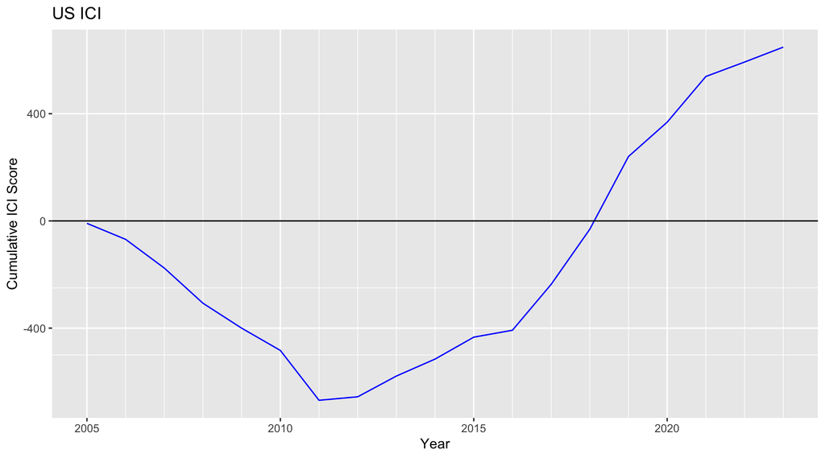

In 2017, many states counties and cities reacted to the restrictionist immigration policies of the new administration by passing a large number of (mostly positive) immigration measures. This [Trump Effect](https://www.nyulawreview.org/issues/volume-94-number-1/subfederal-immigration-regulation-and-the-trump-effect/) can be seen in Figure 2 below. The intensity of this sub-federal response since 2016 has moved the US ICI to positve territory.

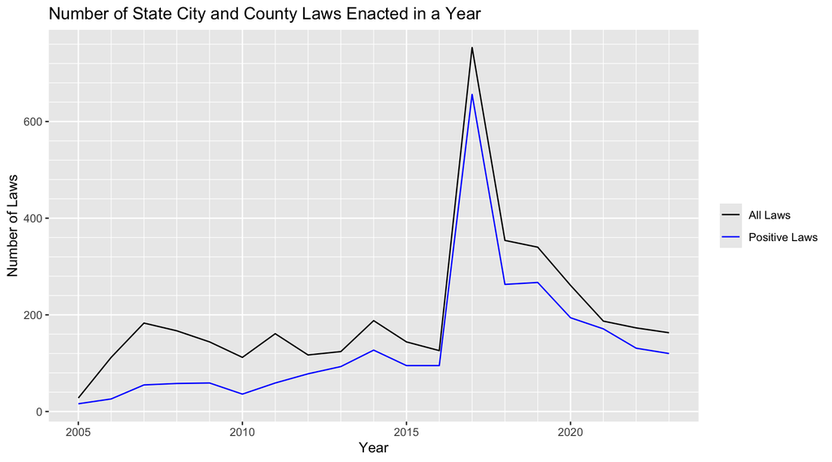

Figure 2a. The Trump Effect: a spike in immigration related legislative activity at the state, county and city levels in 2017, almost all of which generating positive ICI scores.

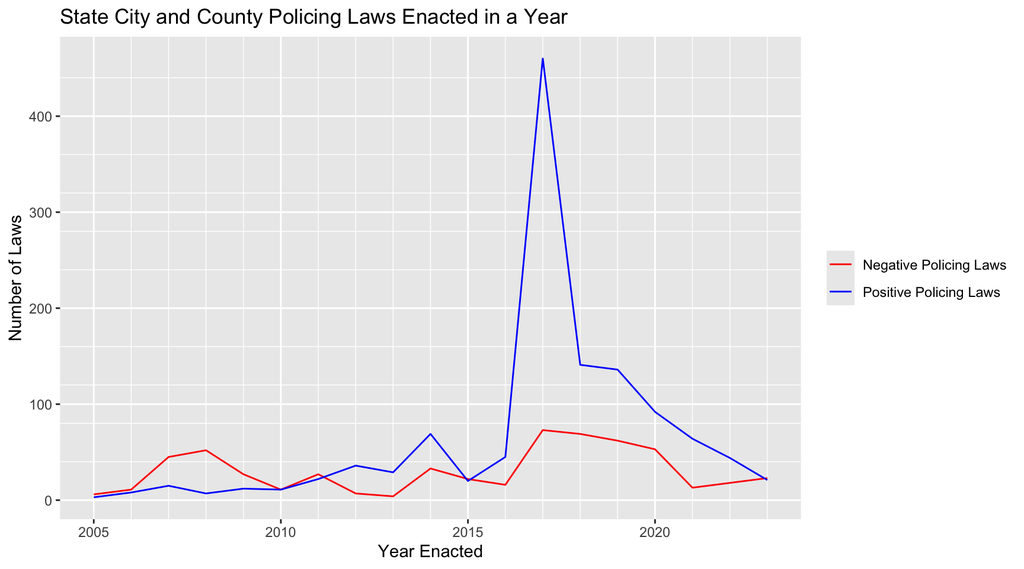

Figure 2b. The Trump Effect: a spike in Positive policing laws at the state, county and city levels in 2017.

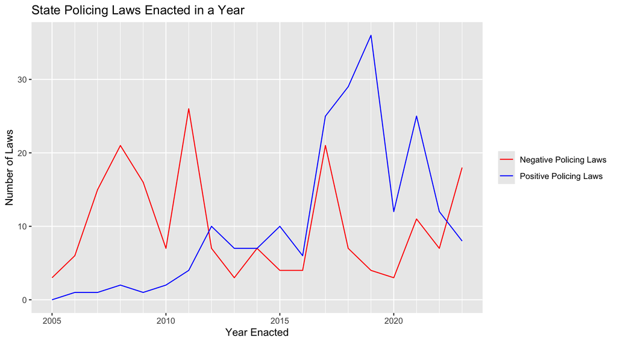

Figure 2c. Negative states were active during the Bush and Obama years, while Positive states were active during Trump.

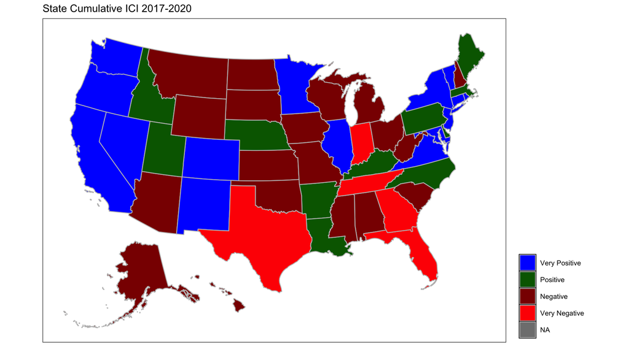

Figure 3. Cumulative ICI scores from State Legislation during the Trump years 2017-2020. (Updated October 2024)

## Methodology: Constructing the ICI

Tier 3 laws (± 3 points) affect a crucial aspect of life for immigrants, an aspect that is difficult for the immigrant to avoid or substitute. We include in this tier laws that make it harder or easier for immigrants to obtain private housing (e.g., laws that require landlords to check the immigration status of tenants), identification (like driver’s licenses), or any kind of employment (e.g., by requiring employers to verify the lawful immigration status of employees or face state or local penalties).

Tier 2 laws (± 2 points) affect an important but not crucial aspect of life for immigrants, an aspect for which immigrants can find alternatives, albeit not easily. This tier includes laws that make it harder or easier for immigrants to obtain specific jobs (including work as day laborers) or specific work licenses (like CPA licenses). The tier also includes laws that restrict or enhance access to government benefits based on immigration status, benefits like welfare programs, workers’ compensation, healthcare, public housing, naturalization and refugee assistance, and education programs.

Finally, Tier 1 laws (± 1 point) affect immigrants’ lives but in a less important or less significant way. Laws in this tier include English-only laws, laws that make it harder or easier for immigrants to vote, or legal services laws (typically laws that regulate the legal market to prevent immigrants from being defrauded).

The laws are weighted by the fraction of the state population that lives in the jurisdiction covered by the law.

We started our data collection with laws enacted in 2005, the year that subfederal immigration regulation began in earnest. Certainly, there was some subfederal enforcement before 2005, but these laws were largely isolated in nature.

For a more detailed discussion on the construction of the ICI and the Local Immigration Laws Database, see the second reference listed below.

## Research Using the Sub-Federal Immigration Laws Database

- [Sub-Federal Immigration Regulation and the Trump Effect](https://ssrn.com/abstract=3171663) (with [Huyen Pham](https://www.law.tamu.edu/faculty/faculty-profiles/huyen-pham.html)) New York University Law Review, vol. 94, no. 1, 2019.
- State-Created Immigration Climates: the Influence of Domestic Migrants ([Huyen Pham](http://law.tamu.edu/Faculty/FacultyProfiles/HuyenPham.aspx) and [Pham Hoang Van](https://www.baylor.edu/Van_Pham/)), University of Hawaii Law Review, vol. 38, no. 1, 2016. pp. 181-210. reprinted in Immigration and Nationality Law Review, University of California—Davis, forthcoming, 2017.
- [Measuring the Climate for Immigrants: A State-by-State Analysis](http://papers.ssrn.com/sol3/papers.cfm?abstract_id=1986128) ([Huyen Pham](https://www.law.tamu.edu/faculty/faculty-profiles/huyen-pham.html) and [Pham Hoang Van](https://www.baylor.edu/Van_Pham/)), in Strange Neighbors: The Role of States in Immigration Policy, Gabriel Jack Chin and Carissa Hessick (eds.) New York University Press, 2014, Chapter 1, pp. 21-40.
- Measuring State-Created Immigration Climate, ([Huyen Pham](https://www.law.tamu.edu/faculty/faculty-profiles/huyen-pham.html) and [Pham Hoang Van](https://www.baylor.edu/Van_Pham/)), in How to Measure Immigration Policies?, Migration and Citizenship Newsletter of the American Political Science Association, 2013.
- The Economic Impact of Subfederal Immigration Regulation: An Empirical Analysis ([Huyen Pham](https://www.law.tamu.edu/faculty/faculty-profiles/huyen-pham.html) and [Pham Hoang Van](https://www.baylor.edu/Van_Pham/)), Cardozo Law Review, vol. 32, no. 2, November 2010, pp. 485-518. reprinted in Immigration and Nationality Law Review, vol. 31, 2012.

##### © 2024 [Huyen Pham](https://www.law.tamu.edu/faculty/faculty-profiles/huyen-pham.html) and [Pham Hoang Van](https://www.baylor.edu/Van_Pham/)